# Station clock screen of every station, catalog v5.1 residuals (D-B090)

### G03D.7D#1 to review

unclear [colocated]; start 2015-01-21T14:07:55Z (sd 1.19 d), end nan [nan .. nan], restart nan; size -0.167 +- 0.017 s (residuals), CC +nan +- nan (n=0); dBIC 74.4, p 0.00498

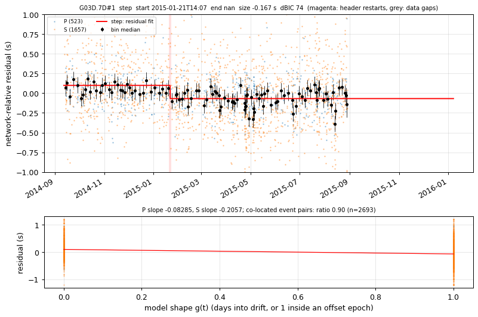

### KHMB.NC#1 to review

unclear [P=S] {colocated~0}; start 2011-06-29T06:37:49Z (sd 207.46 d), end nan [nan .. nan], restart nan; size +4.8072e-05 +- 7.2e-06 s/day (residuals), CC +nan +- nan (n=0); dBIC 73.3, p 0.00498

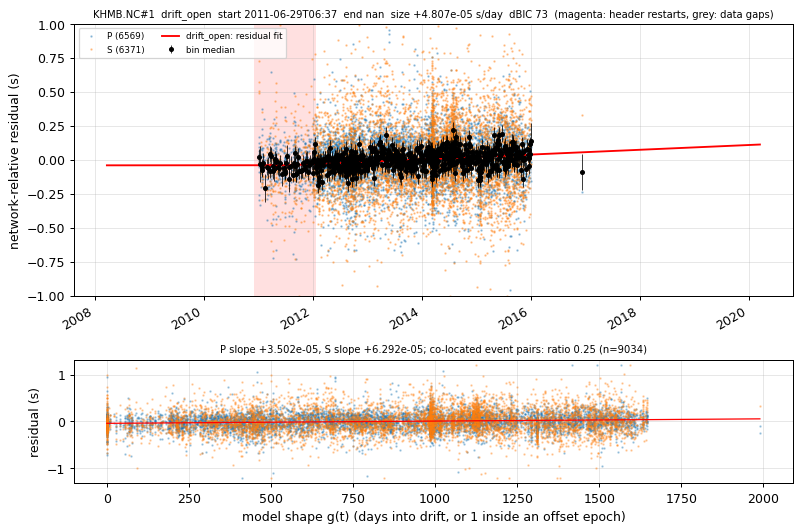

### J28B.7D#1 to review

event-mix-like {colocated~0}; start 2012-09-29T01:43:36Z (sd 0.00 d), end 2012-10-09T03:41:31Z [2012-10-09T02:23:26Z .. 2012-10-09T04:59:37Z], restart nan; size -0.58767 +- 0.073 s (residuals), CC +nan +- nan (n=0); dBIC 72.3, p 0.00498

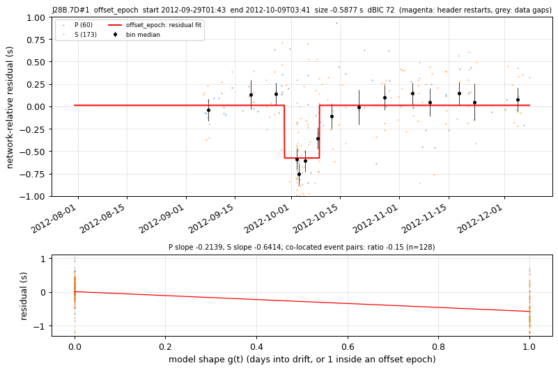

### KRMB.NC#1 to review

event-mix-like {colocated~0}; start 2014-05-12T02:54:02Z (sd 15.59 d), end 2015-10-05T10:49:13Z [2015-10-05T10:49:08Z .. 2015-10-05T10:49:18Z], restart nan; size -0.052313 +- 0.0051 s (residuals), CC +nan +- nan (n=0); dBIC 68.8, p 0.00498

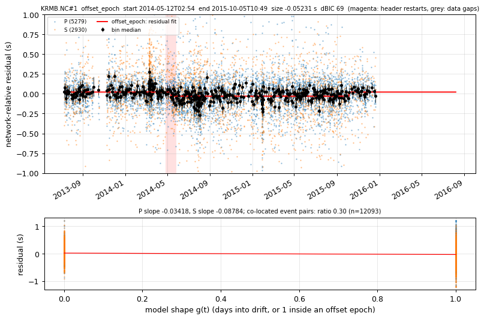

### SHW.UW#1 to review

event-mix-like {colocated~0}; start 2013-08-01T20:10:01Z (sd 5.27 d), end 2013-08-24T14:16:46Z [2013-08-24T13:27:36Z .. 2013-08-24T15:05:56Z], restart nan; size -0.13509 +- 0.034 s (residuals), CC +nan +- nan (n=0); dBIC 67.0, p 0.00498

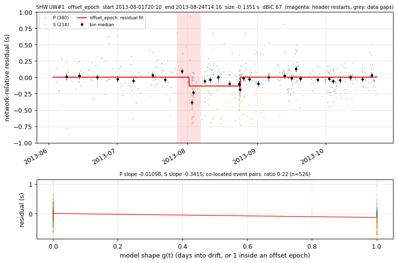

### B039.PB#1 to review

unclear [P=S]; start 2014-03-09T00:18:22Z (sd 0.18 d), end 2014-03-11T19:22:31Z [2014-03-11T19:22:17Z .. 2014-03-11T19:22:44Z], restart nan; size +0.24253 +- 0.023 s/day (residuals), CC +nan +- nan (n=0); dBIC 66.9, p 0.00498

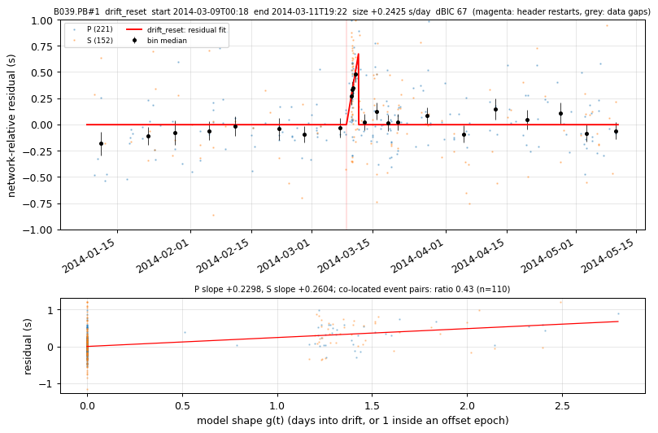

### B040.PB#1 to review

unclear; start 2016-11-02T05:18:40Z (sd 10.75 d), end 2016-12-02T09:59:15Z [2016-11-29T13:15:53Z .. 2016-12-05T06:42:37Z], restart nan; size +0.043159 +- 0.011 s/day (residuals), CC +nan +- nan (n=0); dBIC 66.4, p 0.00498

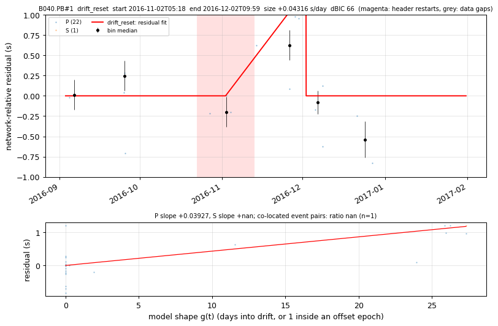

### TXB.CN#1 to review

unclear [P=S]; start 2010-04-07T10:13:39Z (sd 216.62 d), end nan [nan .. nan], restart nan; size -4.7593e-05 +- 6.5e-06 s/day (residuals), CC +nan +- nan (n=0); dBIC 66.1, p 0.00498

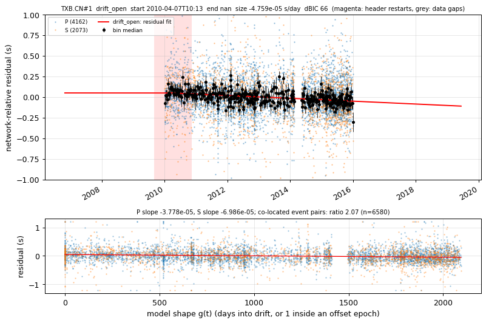

### GB331.Z5#2 to review

unclear [P=S] {colocated~0}; start 2015-04-19T06:34:29Z (sd 2.90 d), end 2015-05-06T00:23:29Z [2015-05-06T00:23:25Z .. 2015-05-06T00:23:32Z], restart nan; size +0.018084 +- 0.006 s/day (residuals), CC +nan +- nan (n=0); dBIC 65.0, p 0.00498

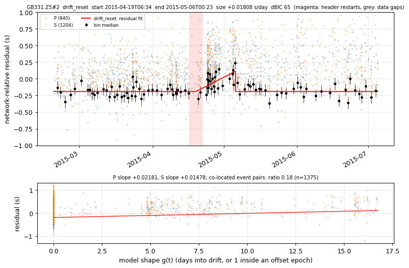

### B047.PB#1 to review

unclear [P=S] {colocated~0}; start 2015-01-24T16:37:43Z (sd 25.73 d), end 2015-02-01T11:58:56Z [2015-02-01T11:58:19Z .. 2015-02-01T11:59:34Z], restart nan; size +0.014375 +- 0.007 s/day (residuals), CC +nan +- nan (n=0); dBIC 64.4, p 0.00498

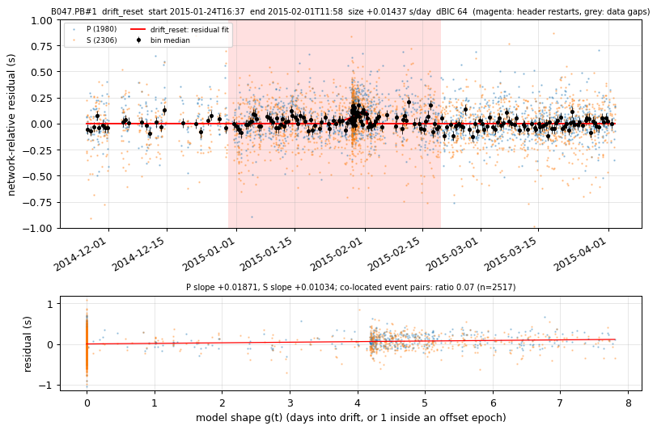

### OZB.CN#2 to review

event-mix-like {colocated~0}; start 2012-11-04T23:54:21Z (sd 1.87 d), end 2012-11-21T13:50:07Z [2012-11-21T05:33:19Z .. 2012-11-21T22:06:54Z], restart nan; size -0.35741 +- 0.095 s (residuals), CC +nan +- nan (n=0); dBIC 63.8, p 0.00498

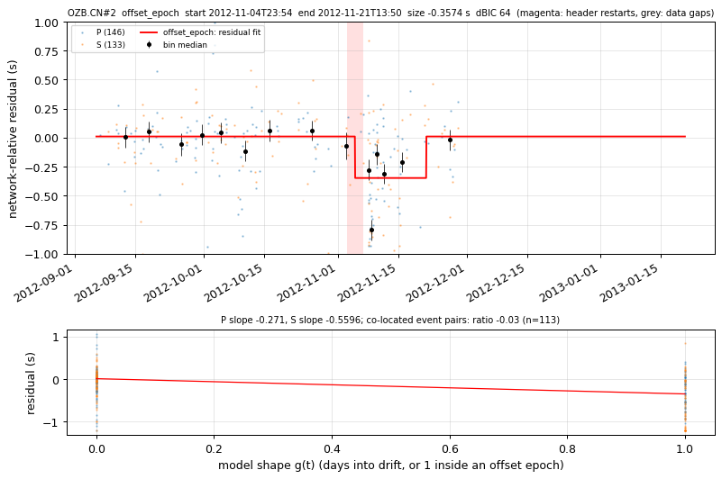

### N02D.TA#1 to review

event-mix-like {colocated~0}; start 2014-03-08T23:58:29Z (sd 5.12 d), end 2014-03-11T22:18:35Z [2014-03-11T21:33:45Z .. 2014-03-11T23:03:25Z], restart nan; size +0.13404 +- 0.045 s/day (residuals), CC +nan +- nan (n=0); dBIC 63.0, p 0.00498

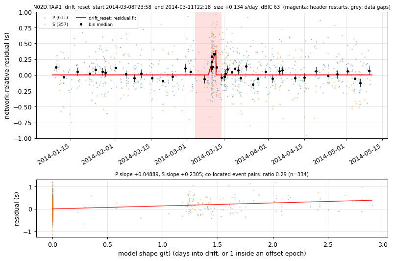

### STD.UW#1 to review

unclear [P=S] {CC~0}; start 2010-01-17T21:49:18Z (sd 166.36 d), end nan [nan .. nan], restart nan; size +4.7866e-05 +- 7.9e-06 s/day (residuals), CC +1.1937e-05 +- 1.6e-05 (n=62); dBIC 62.2, p 0.00498

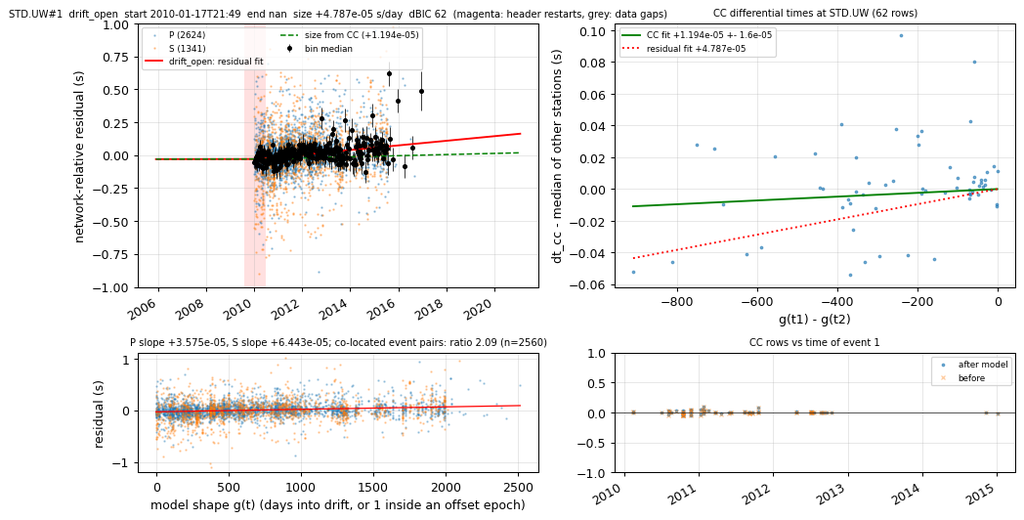

### MTM.UW#1 to review

unclear [colocated] {CC~0}; start 2013-08-24T17:05:22Z (sd 167.73 d), end 2016-05-15T07:42:16Z [2016-05-15T07:35:15Z .. 2016-05-15T07:49:17Z], restart nan; size +6.6753e-05 +- 1.5e-05 s/day (residuals), CC -5.6005e-06 +- 5.3e-05 (n=34); dBIC 61.6, p 0.00498

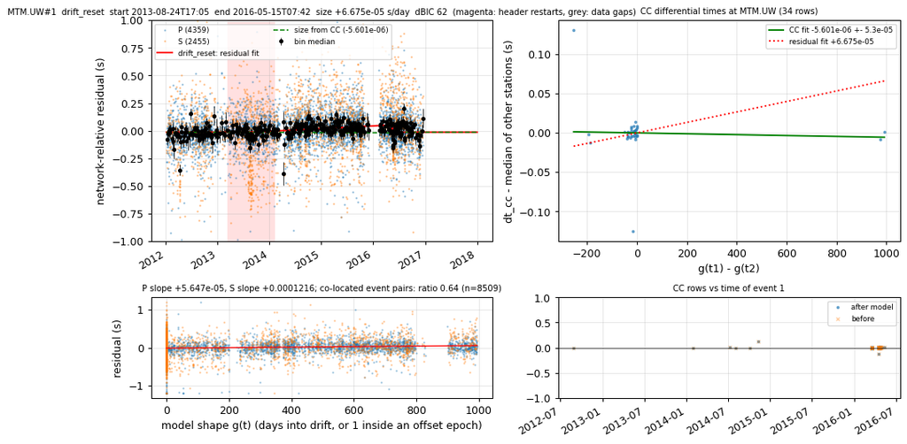

### B926.PB#1 to review

event-mix-like {colocated~0}; start 2015-05-29T11:43:03Z (sd 0.51 d), end 2015-06-05T00:59:40Z [2015-06-05T00:01:22Z .. 2015-06-05T01:57:57Z], restart nan; size +0.10991 +- 0.031 s/day (residuals), CC +nan +- nan (n=0); dBIC 59.5, p 0.00498

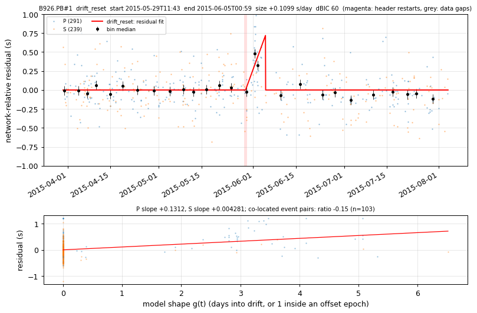

### G28B.7D#1 to review

unclear [colocated]; start 2012-10-23T01:06:24Z (sd 25.02 d), end nan [nan .. nan], restart nan; size -0.0015959 +- 0.00029 s/day (residuals), CC +nan +- nan (n=0); dBIC 58.8, p 0.00498

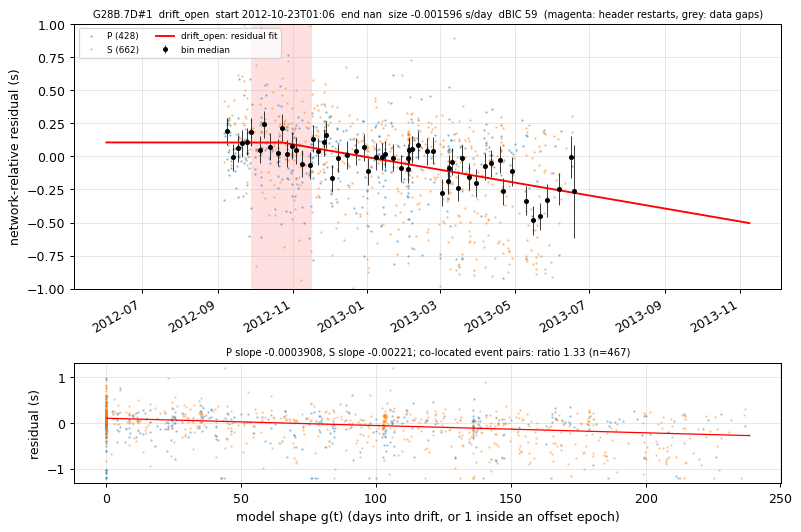

### B049.PB#2 to review

event-mix-like {colocated~0}; start 2015-01-28T21:18:34Z (sd 1.16 d), end 2015-02-01T07:44:06Z [2015-02-01T07:20:51Z .. 2015-02-01T08:07:21Z], restart nan; size +0.12219 +- 0.014 s (residuals), CC +nan +- nan (n=0); dBIC 58.3, p 0.00498

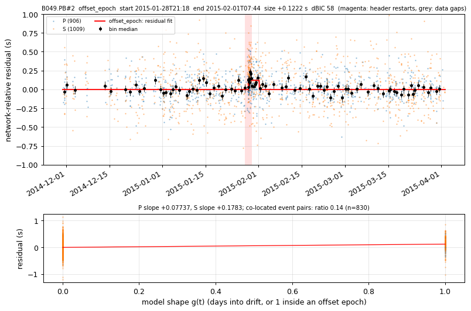

### J30C.7D#1 to review

event-mix-like {colocated~0}; start 2014-03-11T16:33:30Z (sd 2.96 d), end 2014-03-23T06:13:57Z [2014-03-23T06:13:48Z .. 2014-03-23T06:14:05Z], restart nan; size -0.1863 +- 0.02 s (residuals), CC +nan +- nan (n=0); dBIC 57.6, p 0.00498

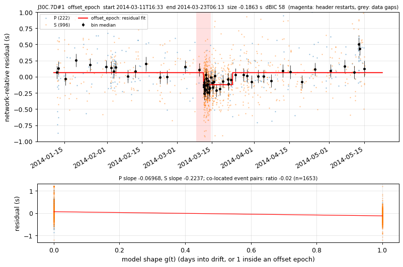

### GB210.Z5#1 to review

unclear; start 2014-02-28T23:45:17Z (sd 5.89 d), end 2014-03-18T07:24:11Z [2014-03-18T06:51:17Z .. 2014-03-18T07:57:05Z], restart nan; size +0.005947 +- 0.0018 s/day (residuals), CC +nan +- nan (n=0); dBIC 56.8, p 0.00498

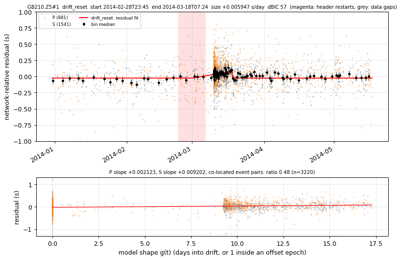

### AXAS2.OO#2 to review

event-mix-like {colocated~0}; start 2015-03-09T15:13:47Z (sd 9.85 d), end 2015-12-29T19:08:49Z [2015-12-29T06:36:54Z .. 2015-12-30T07:40:45Z], restart nan; size +0.00020979 +- 3e-05 s/day (residuals), CC +nan +- nan (n=0); dBIC 56.5, p 0.00498

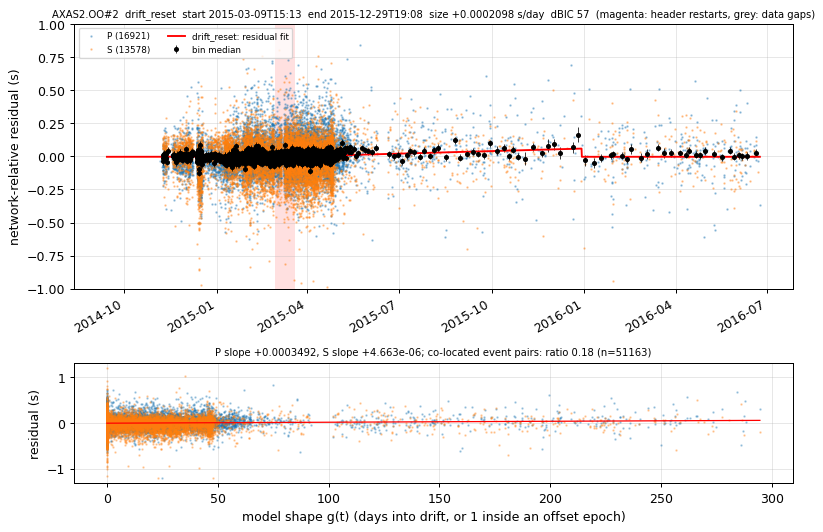

### KCR.NC#1 to review

clock-like [colocated,P=S]; start 2014-07-03T15:55:11Z (sd 67.42 d), end 2015-07-28T23:40:47Z [2015-07-28T17:17:04Z .. 2015-07-29T06:04:31Z], restart nan; size +0.00014803 +- 4.5e-05 s/day (residuals), CC +nan +- nan (n=0); dBIC 55.5, p 0.00498

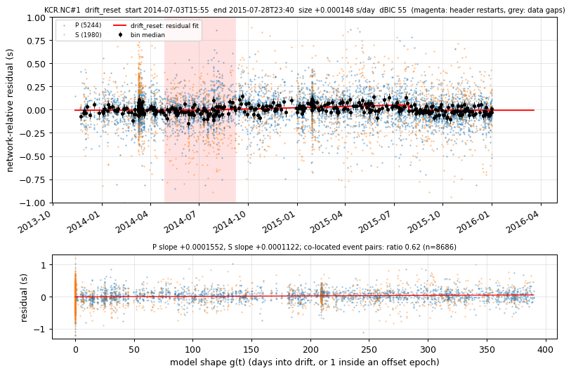

### KEB.NC#1 to review

unclear; start 2013-02-03T03:17:55Z (sd 0.26 d), end 2013-03-09T17:32:14Z [2013-03-04T03:43:17Z .. 2013-03-15T07:21:11Z], restart nan; size -0.050725 +- 0.0017 s/day (residuals), CC +nan +- nan (n=0); dBIC 54.1, p 0.00498

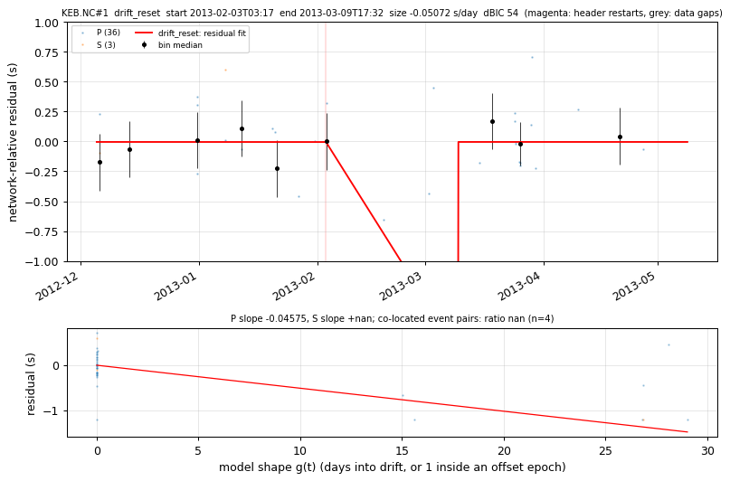

### MQ07.XD#1 to review

event-mix-like {colocated~0,P/S opposite}; start 2015-05-29T08:26:30Z (sd 125.62 d), end 2015-06-02T16:09:30Z [2015-06-02T14:27:51Z .. 2015-06-02T17:51:09Z], restart nan; size -0.09007 +- 0.067 s/day (residuals), CC +nan +- nan (n=0); dBIC 54.1, p 0.00498

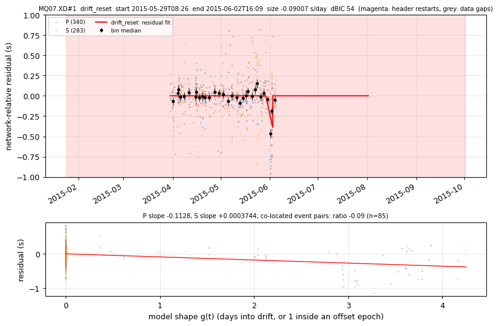

### LVP.UW#1 to review

unclear [colocated,P=S] {CC~0}; start 2014-03-24T11:19:33Z (sd 106.85 d), end nan [nan .. nan], restart nan; size +8.4904e-05 +- 2.5e-05 s/day (residuals), CC +2.8181e-05 +- 4.7e-05 (n=11); dBIC 53.1, p 0.00498

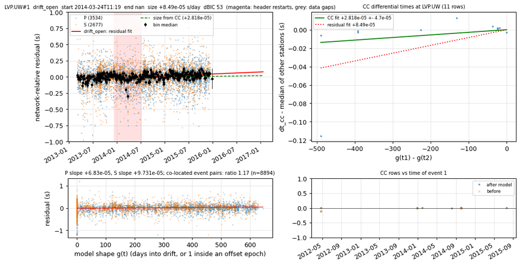

### BB630.Z5#1 to review

unclear; start 2014-03-04T20:11:28Z (sd 0.00 d), end 2014-03-08T18:22:10Z [2014-03-08T18:17:52Z .. 2014-03-08T18:26:27Z], restart nan; size +0.25417 +- 0.059 s (residuals), CC +nan +- nan (n=0); dBIC 53.0, p 0.00498

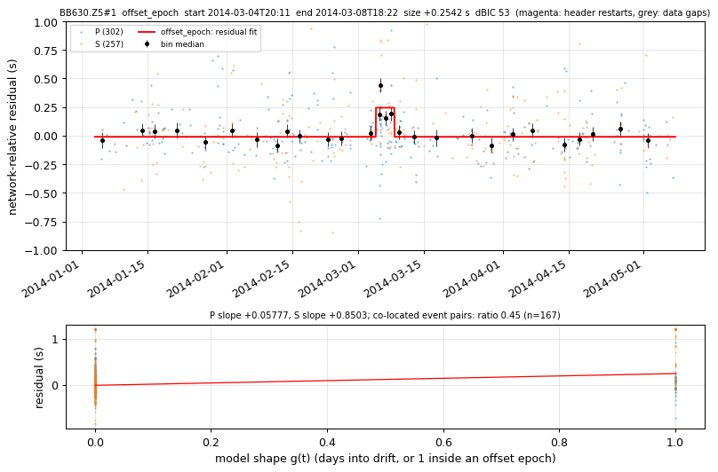

### BB530.X9#1 to review

unclear [P=S] {colocated~0}; start 2012-10-14T19:38:00Z (sd 3.29 d), end nan [nan .. nan], restart nan; size +0.11848 +- 0.013 s (residuals), CC +nan +- nan (n=0); dBIC 52.8, p 0.00498

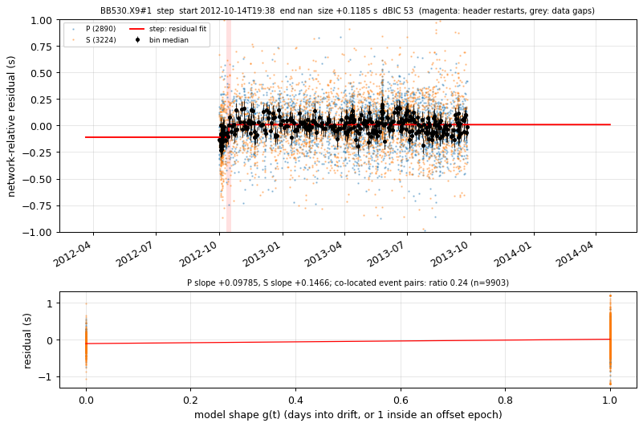

### MH03.XD#1 to review

event-mix-like {colocated~0,P/S opposite}; start 2016-05-13T22:30:41Z (sd 92.39 d), end 2016-05-17T05:14:58Z [2016-05-17T01:56:41Z .. 2016-05-17T08:33:15Z], restart nan; size +0.082984 +- 0.04 s/day (residuals), CC +nan +- nan (n=4); dBIC 51.8, p 0.00498

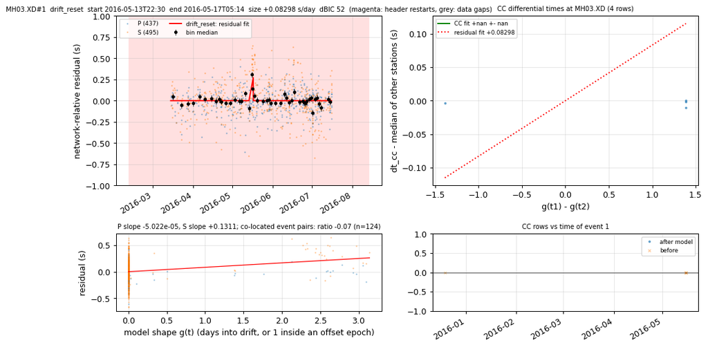

### FS13D.7D#1 to review

event-mix-like {colocated~0}; start 2015-01-28T20:31:03Z (sd 0.06 d), end 2015-02-02T13:41:43Z [2015-02-02T13:41:41Z .. 2015-02-02T13:41:46Z], restart nan; size +0.142 +- 0.019 s (residuals), CC +nan +- nan (n=0); dBIC 51.2, p 0.00498

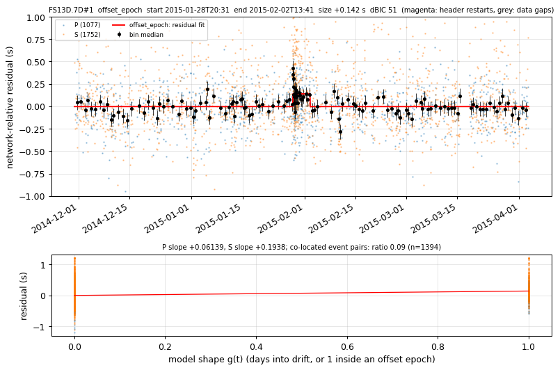

### B011.PB#1 to review

event-mix-like {colocated~0,P/S opposite}; start 2014-04-12T23:48:56Z (sd 44.94 d), end 2014-04-24T23:49:54Z [2014-04-24T23:47:39Z .. 2014-04-24T23:52:10Z], restart nan; size +0.021101 +- 0.0064 s/day (residuals), CC +nan +- nan (n=0); dBIC 50.6, p 0.00498

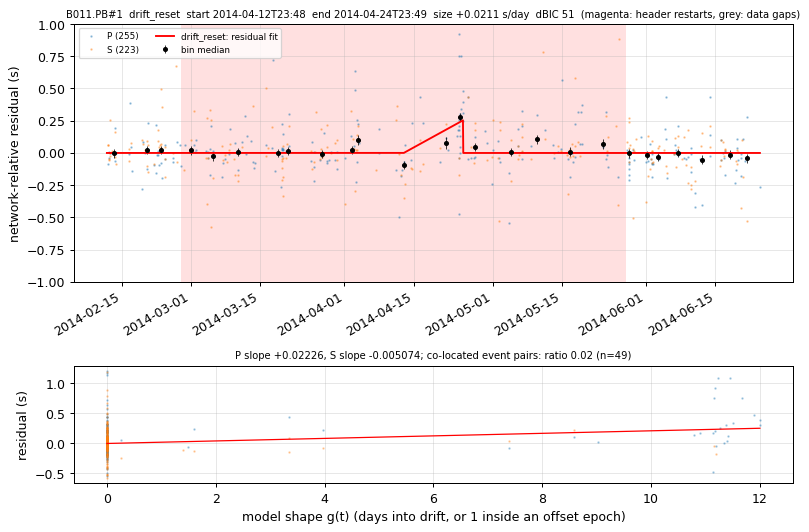

### GB260.Z5#1 to review

event-mix-like {colocated~0}; start 2014-03-09T22:36:34Z (sd 1.51 d), end nan [nan .. nan], restart nan; size -0.08294 +- 0.01 s (residuals), CC +nan +- nan (n=0); dBIC 48.0, p 0.00498

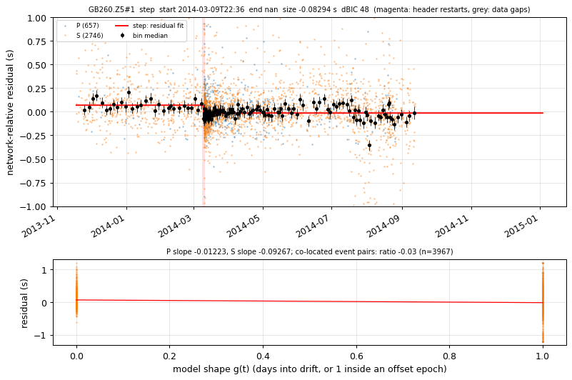

### BB130.X9#2 to review

clock-like [colocated,P=S]; start 2012-11-01T16:25:46Z (sd 25.17 d), end 2013-06-06T13:30:26Z [2013-06-06T13:29:53Z .. 2013-06-06T13:30:59Z], restart nan; size +0.058828 +- 0.013 s (residuals), CC +nan +- nan (n=0); dBIC 46.7, p 0.00498

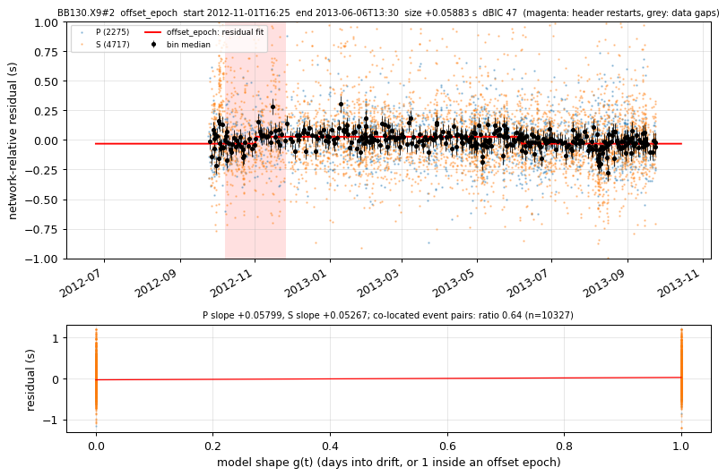

### SHB.CN#1 to review

unclear; start 2013-03-01T00:32:39Z (sd 251.78 d), end nan [nan .. nan], restart nan; size +8.9315e-05 +- 1.8e-05 s/day (residuals), CC +nan +- nan (n=0); dBIC 46.0, p 0.00498

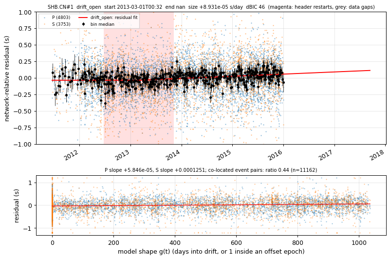

### FS06D.7D#1 to review

event-mix-like {colocated~0}; start 2014-10-12T04:13:43Z (sd 5.88 d), end nan [nan .. nan], restart nan; size -0.082966 +- 0.015 s (residuals), CC +nan +- nan (n=0); dBIC 45.1, p 0.00498

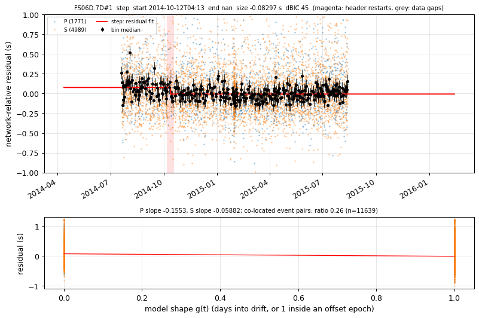

### G27B.7D#1 to review

clock-like [colocated,P=S]; start 2013-01-29T00:33:44Z (sd 3.87 d), end nan [nan .. nan], restart nan; size +0.14945 +- 0.02 s (residuals), CC +nan +- nan (n=0); dBIC 44.7, p 0.00498

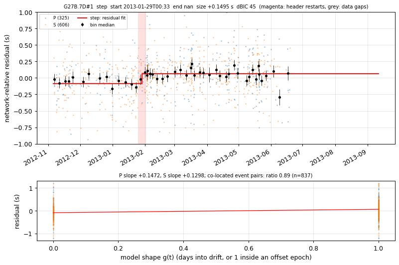

### MG06.XD#1 to review

unclear [P=S] {colocated~0,CC~0}; start 2016-04-21T15:24:58Z (sd 4.13 d), end 2016-05-18T22:40:41Z [2016-05-18T22:40:37Z .. 2016-05-18T22:40:45Z], restart nan; size +0.07296 +- 0.011 s (residuals), CC +0.0022123 +- 0.0014 (n=272); dBIC 44.6, p 0.00498

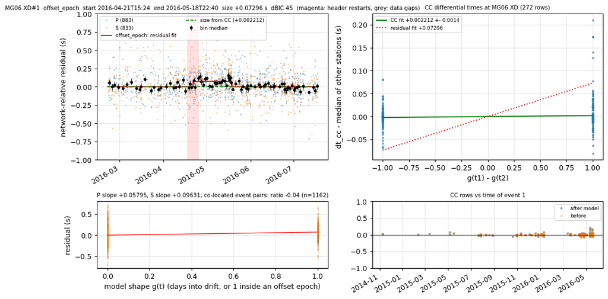

### PCFR.UW#1 to review

clock-like [colocated,P=S]; start 2011-01-27T15:32:37Z (sd 17.48 d), end 2011-04-06T06:29:29Z [2011-03-19T02:23:59Z .. 2011-04-24T10:34:59Z], restart nan; size -0.31749 +- 0.082 s (residuals), CC +nan +- nan (n=0); dBIC 43.9, p 0.00498

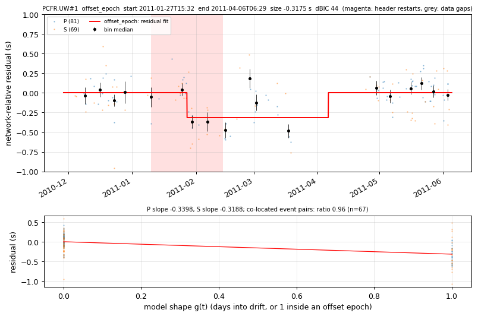

### STD.CC#1 to review

unclear [P=S] {colocated~0}; start 2013-07-30T03:16:39Z (sd 4.19 d), end 2013-09-08T21:41:13Z [2013-09-08T19:47:33Z .. 2013-09-08T23:34:52Z], restart nan; size -0.065444 +- 0.005 s (residuals), CC +nan +- nan (n=3); dBIC 42.4, p 0.00498

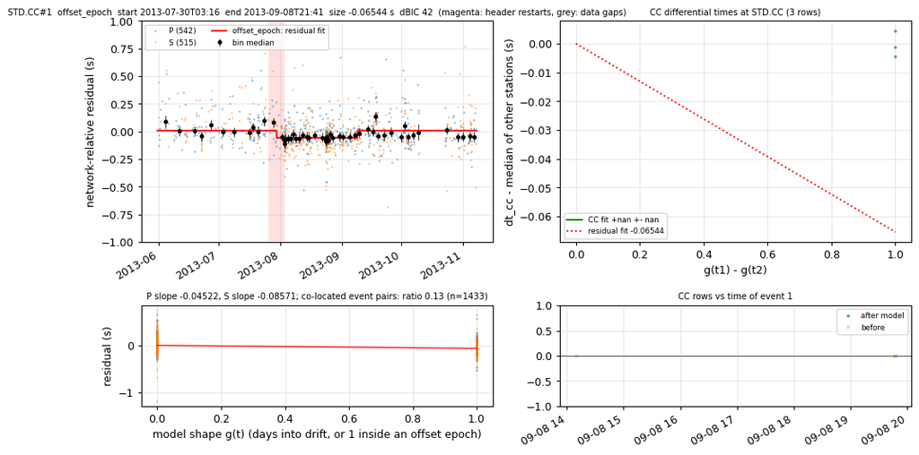

### J21C.7D#1 to review

unclear [P=S]; start 2013-09-14T17:10:07Z (sd 9.76 d), end 2014-02-23T23:37:32Z [2014-02-23T22:09:01Z .. 2014-02-24T01:06:03Z], restart nan; size +0.21085 +- 0.028 s (residuals), CC +nan +- nan (n=0); dBIC 41.3, p 0.00498

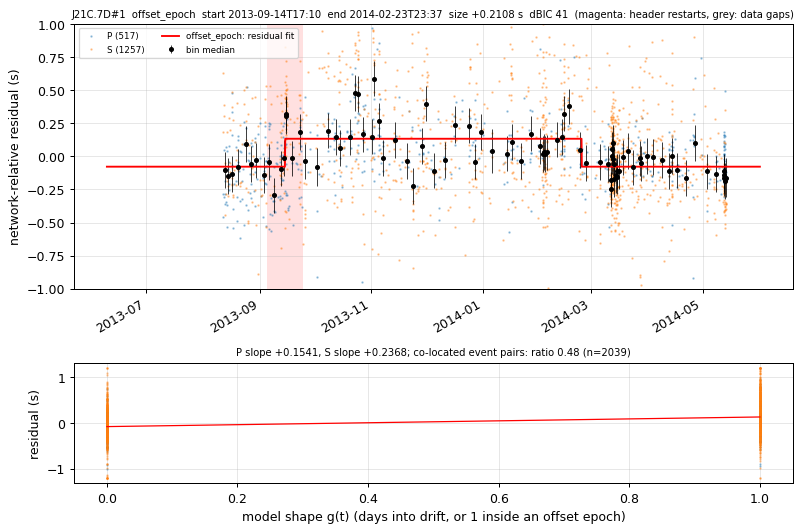

### GB260.Z5#2 to review

unclear [colocated] {P/S opposite}; start 2014-03-10T05:21:55Z (sd 18.32 d), end 2014-07-19T01:50:19Z [2014-07-19T00:03:44Z .. 2014-07-19T03:36:54Z], restart nan; size +0.00082068 +- 0.00018 s/day (residuals), CC +nan +- nan (n=0); dBIC 41.1, p 0.00498

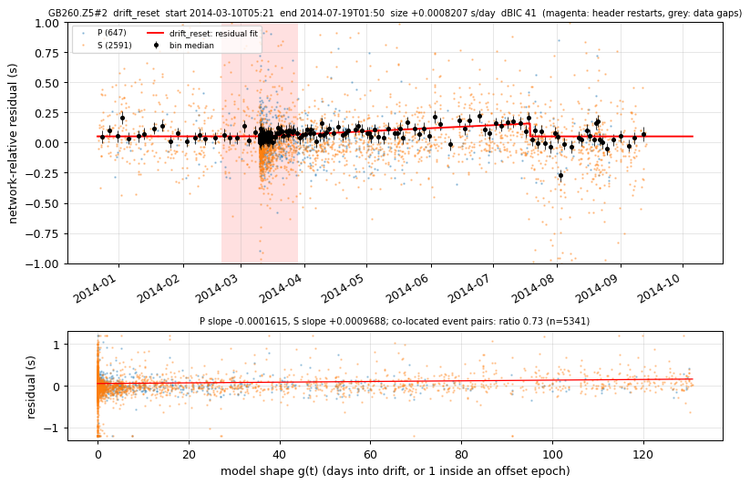

### B202.PB#2 to review

unclear [P=S] {colocated~0}; start 2016-11-01T11:02:01Z (sd 481.76 d), end 2016-11-25T21:37:58Z [2016-11-25T21:07:20Z .. 2016-11-25T22:08:37Z], restart nan; size -0.006274 +- 0.024 s/day (residuals), CC +nan +- nan (n=2); dBIC 40.5, p 0.00498

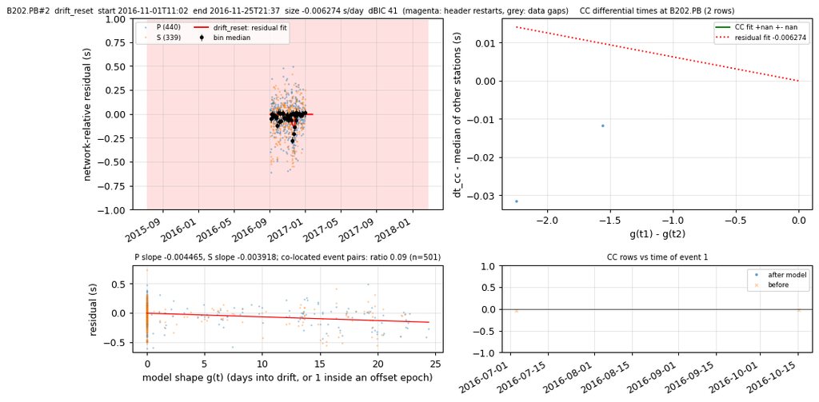

### JCC.BK#1 to review

unclear [P=S] {colocated~0}; start 2015-01-28T09:12:24Z (sd 4.65 d), end 2015-02-01T19:15:47Z [2015-02-01T19:15:13Z .. 2015-02-01T19:16:21Z], restart nan; size -0.14044 +- 0.02 s (residuals), CC +nan +- nan (n=0); dBIC 40.3, p 0.00498

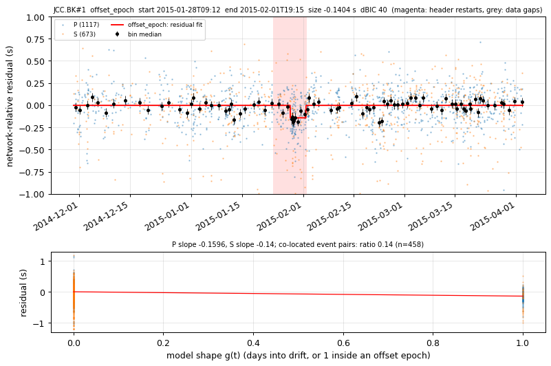

### BB720.Z5#1 to review

event-mix-like {colocated~0}; start 2014-02-02T11:01:37Z (sd 0.00 d), end 2014-02-04T14:16:41Z [2014-02-04T14:10:32Z .. 2014-02-04T14:22:51Z], restart nan; size +0.16271 +- 0.02 s (residuals), CC +nan +- nan (n=0); dBIC 40.0, p 0.00498

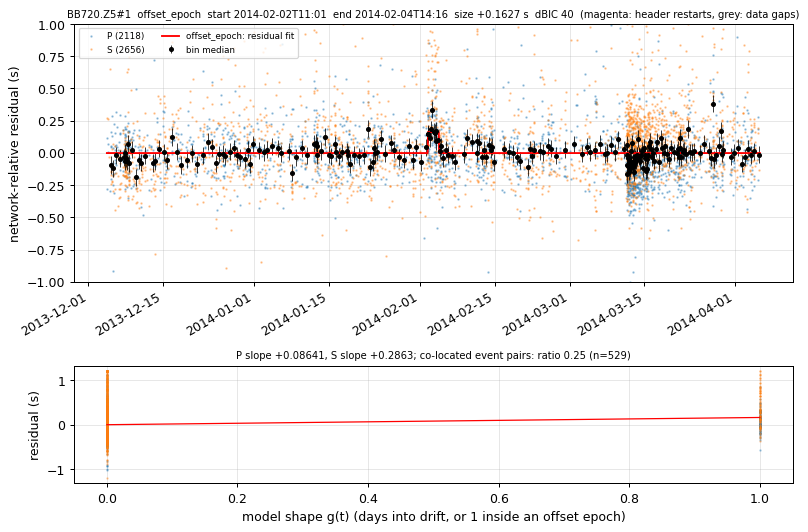

### BB850.Z5#1 to review

clock-like [colocated,P=S]; start 2014-10-26T14:23:40Z (sd 5.53 d), end nan [nan .. nan], restart nan; size -0.073226 +- 0.0094 s (residuals), CC +nan +- nan (n=0); dBIC 39.4, p 0.00498

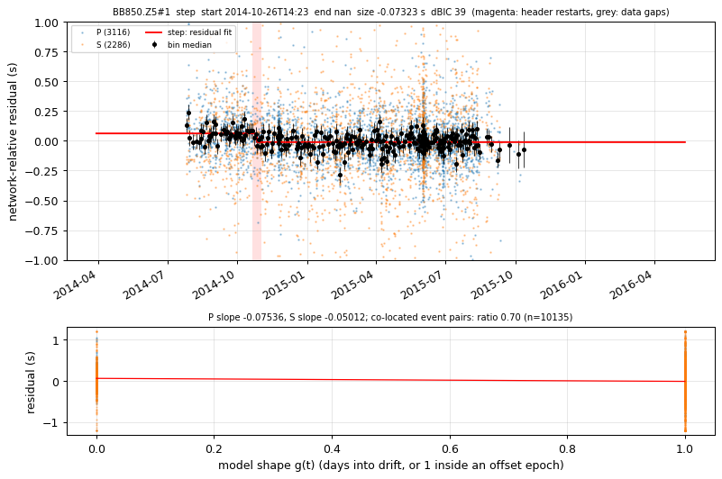

### SOS.UW#1 to review

unclear [P=S] {colocated~0}; start 2011-01-25T23:41:22Z (sd 13.98 d), end 2011-05-27T10:29:23Z [2011-05-27T10:29:14Z .. 2011-05-27T10:29:31Z], restart nan; size -0.057735 +- 0.0065 s (residuals), CC +nan +- nan (n=9); dBIC 39.3, p 0.00498

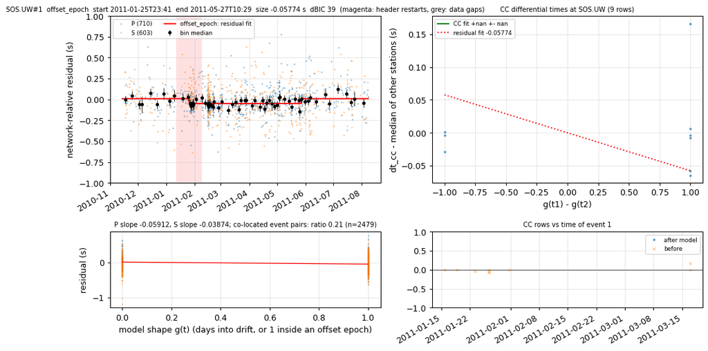

### J18D.7D#1 to review

event-mix-like {colocated~0}; start 2015-06-02T11:09:15Z (sd 1.99 d), end 2015-06-29T07:50:25Z [2015-06-28T12:00:09Z .. 2015-06-30T03:40:41Z], restart nan; size -0.050299 +- 0.0052 s/day (residuals), CC +nan +- nan (n=0); dBIC 38.8, p 0.00995

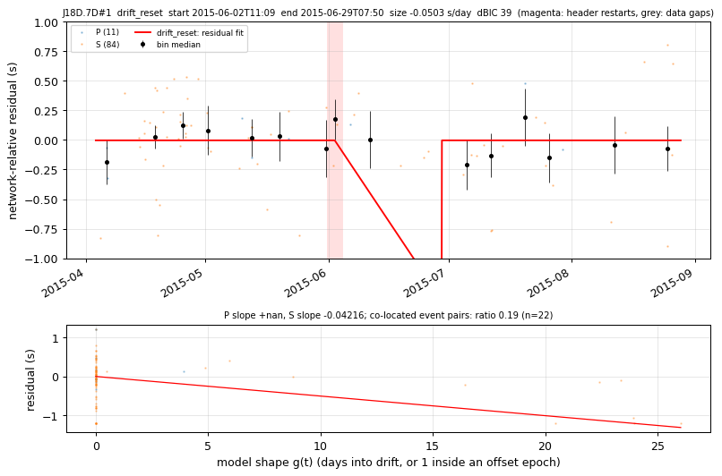

### TDL.UW#1 to review

event-mix-like {colocated~0}; start 2016-05-05T23:19:37Z (sd 4.32 d), end 2016-05-18T07:54:38Z [2016-05-18T07:54:35Z .. 2016-05-18T07:54:40Z], restart nan; size +0.013581 +- 0.0051 s/day (residuals), CC +0.00072099 +- 0.0003 (n=130); dBIC 38.8, p 0.00498

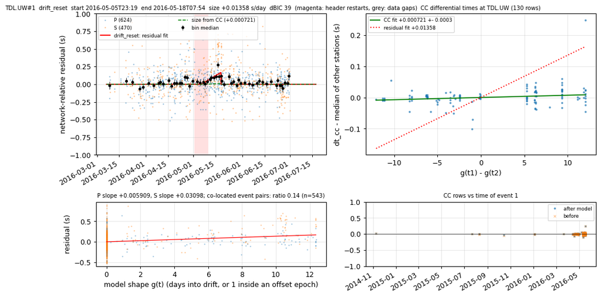

### IRO.UO#1 to review

clock-like [colocated,P=S]; start 2014-08-14T22:06:55Z (sd 174.68 d), end 2014-11-29T04:02:33Z [2014-11-26T19:32:49Z .. 2014-12-01T12:32:16Z], restart nan; size +0.4079 +- 0.11 s (residuals), CC +nan +- nan (n=0); dBIC 38.3, p 0.00498

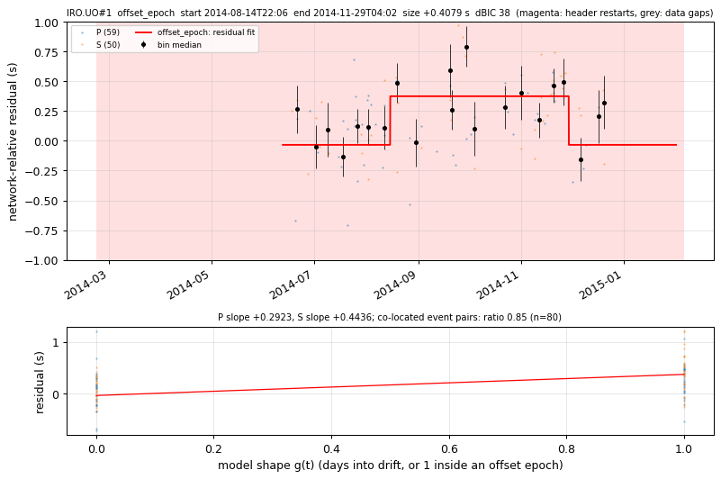

### MQ07.XD#2 to review

event-mix-like {colocated~0,CC~0}; start 2016-05-15T07:42:17Z (sd 0.00 d), end 2016-05-19T11:27:20Z [2016-05-19T11:27:09Z .. 2016-05-19T11:27:31Z], restart nan; size -0.1258 +- 0.017 s (residuals), CC +0.0065805 +- 0.0062 (n=22); dBIC 38.0, p 0.00498

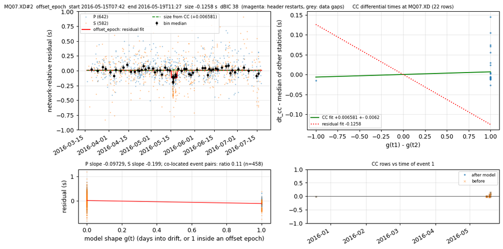

### BB680.Z5#1 to review

clock-like [colocated,P=S]; start 2014-03-11T18:25:27Z (sd 1.12 d), end 2014-03-15T11:15:58Z [2014-03-15T10:35:24Z .. 2014-03-15T11:56:31Z], restart nan; size -0.10405 +- 0.015 s (residuals), CC +nan +- nan (n=0); dBIC 37.4, p 0.00498

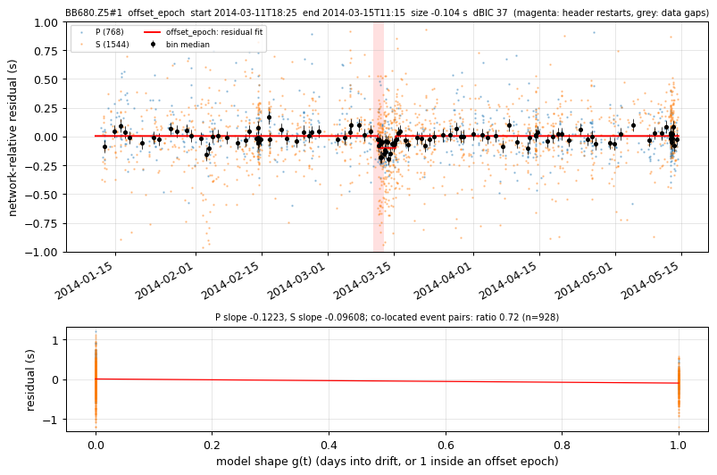

### VDB.CN#1 to review

clock-like [colocated,P=S]; start 2012-02-21T10:49:57Z (sd 82.79 d), end 2014-10-08T01:27:24Z [2014-10-07T01:22:06Z .. 2014-10-09T01:32:41Z], restart nan; size +0.052944 +- 0.0072 s (residuals), CC +nan +- nan (n=0); dBIC 36.9, p 0.00498

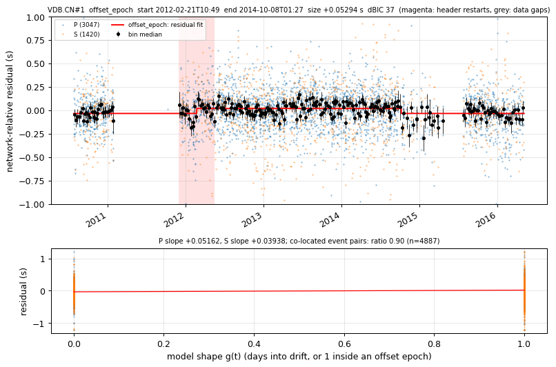

### SEP.CC#1 to review

unclear [P=S] {colocated~0}; start 2013-04-09T03:35:51Z (sd 126.26 d), end 2013-08-26T21:03:35Z [2013-08-26T17:35:37Z .. 2013-08-27T00:31:34Z], restart nan; size +0.0016419 +- 0.0012 s/day (residuals), CC +nan +- nan (n=1); dBIC 36.8, p 0.00498

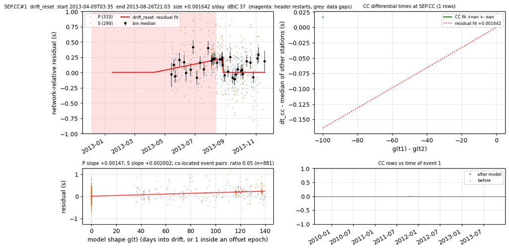

### J28D.7D#1 to review

unclear [P=S] {colocated~0}; start 2015-06-01T06:08:31Z (sd 2.36 d), end 2015-06-03T19:37:01Z [2015-06-03T14:04:26Z .. 2015-06-04T01:09:35Z], restart nan; size -0.62364 +- 0.085 s (residuals), CC +nan +- nan (n=0); dBIC 36.6, p 0.00498

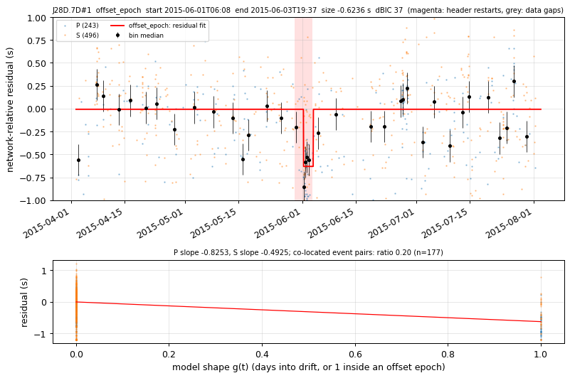

### BB840.Z5#1 to review

event-mix-like {P/S opposite}; start 2014-08-11T00:00:13Z (sd 49.06 d), end nan [nan .. nan], restart nan; size -0.0002767 +- 7.6e-05 s/day (residuals), CC +nan +- nan (n=0); dBIC 36.1, p 0.00498

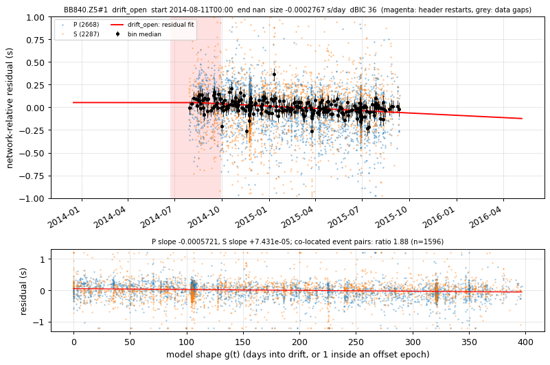

### J23C.7D#1 to review

unclear; start 2013-11-23T08:01:30Z (sd 0.22 d), end 2013-11-30T16:00:31Z [2013-11-30T09:34:28Z .. 2013-11-30T22:26:34Z], restart nan; size +0.18111 +- 0.031 s (residuals), CC +nan +- nan (n=0); dBIC 35.9, p 0.00498

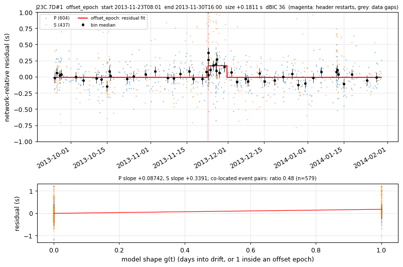

### FS14B.7D#1 to review

unclear [P=S]; start 2012-09-11T23:04:59Z (sd 9.16 d), end nan [nan .. nan], restart nan; size -0.0035795 +- 0.00076 s/day (residuals), CC +nan +- nan (n=0); dBIC 35.5, p 0.00498

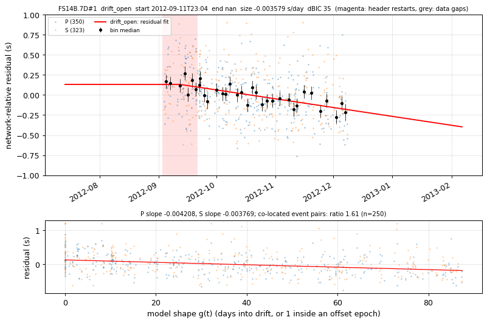

### FS44D.7D#1 to review

clock-like [colocated,P=S]; start 2015-08-11T01:57:47Z (sd 0.25 d), end nan [nan .. nan], restart nan; size +0.15732 +- 0.032 s (residuals), CC +nan +- nan (n=0); dBIC 35.3, p 0.00498

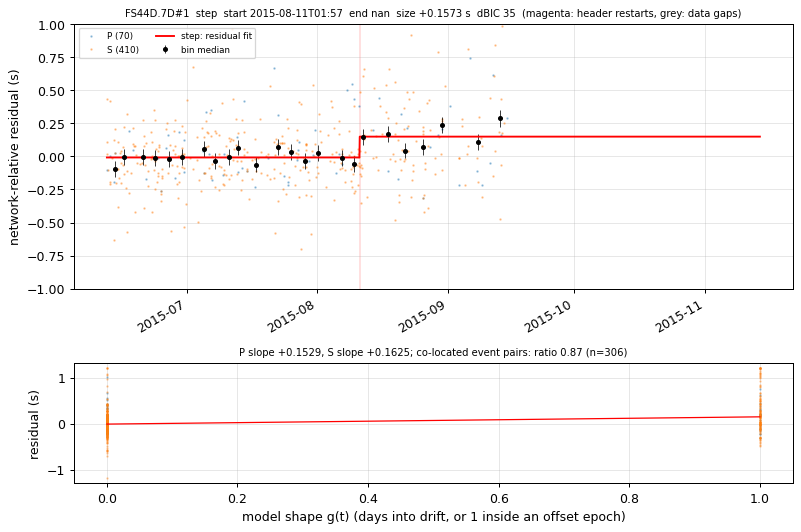

### J19B.7D#1 to review

event-mix-like {colocated~0}; start 2012-10-06T16:50:12Z (sd 3.55 d), end nan [nan .. nan], restart nan; size -0.34128 +- 0.076 s (residuals), CC +nan +- nan (n=0); dBIC 34.7, p 0.00498

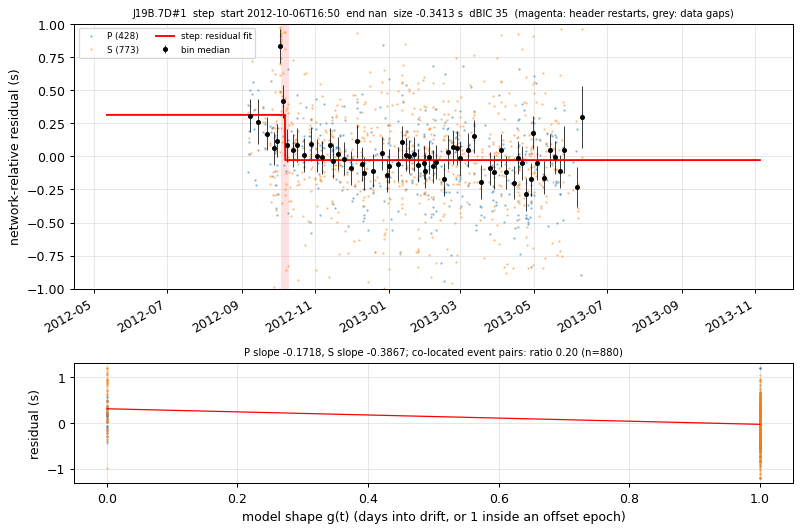

### KJJ.NC#1 to review

unclear [colocated]; start 2012-09-09T17:34:00Z (sd 0.92 d), end nan [nan .. nan], restart nan; size -0.081808 +- 0.012 s (residuals), CC +nan +- nan (n=0); dBIC 34.4, p 0.00498

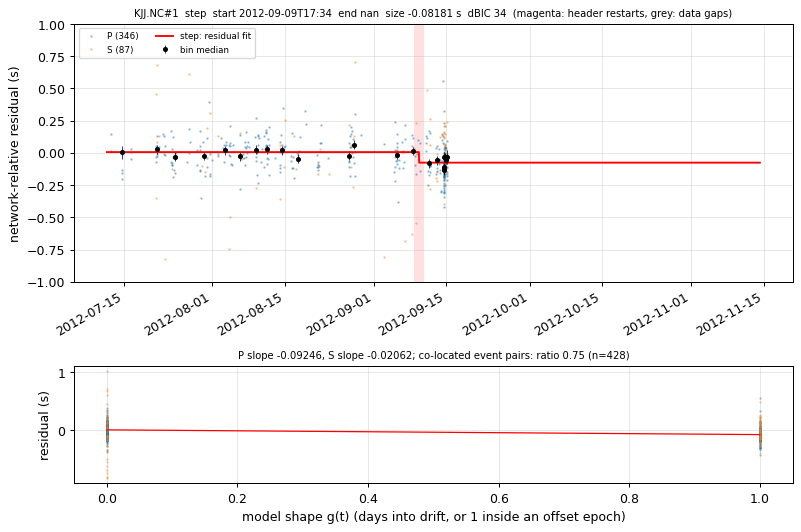

### CLMS.CC#1 to review

unclear [colocated]; start 2011-06-22T16:51:11Z (sd 21.73 d), end 2013-10-01T21:06:45Z [2013-08-25T07:25:47Z .. 2013-11-08T10:47:43Z], restart nan; size -0.0024929 +- 0.00017 s/day (residuals), CC +nan +- nan (n=0); dBIC 34.4, p 0.00498

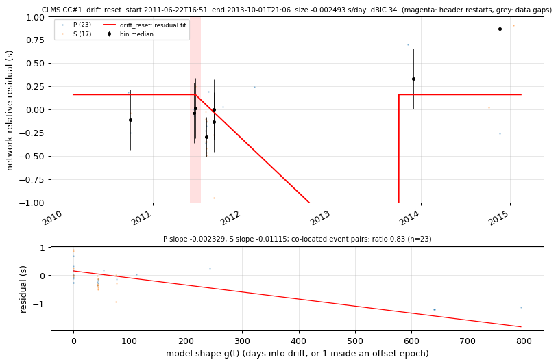

### MH04.XD#1 to review

event-mix-like {colocated~0,P/S opposite}; start 2016-05-15T06:36:58Z (sd 37.32 d), end 2016-05-19T15:55:43Z [2016-05-19T11:27:17Z .. 2016-05-19T20:24:09Z], restart nan; size +0.094758 +- 0.028 s (residuals), CC +0.0086077 +- 0.0035 (n=12); dBIC 34.0, p 0.00498

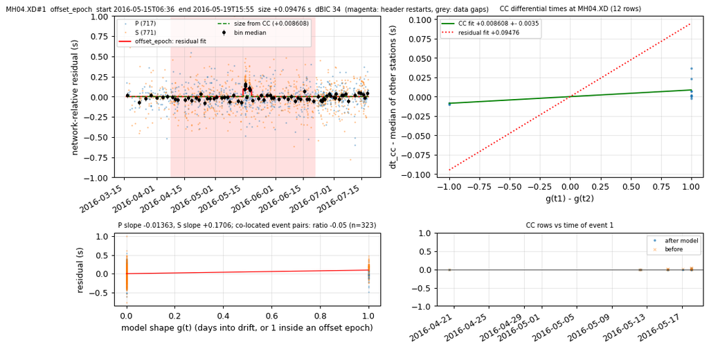

### BB710.Z5#2 to review

unclear [P=S] {colocated~0}; start 2013-11-22T15:19:39Z (sd 40.37 d), end 2013-11-25T00:38:18Z [2013-11-25T00:38:15Z .. 2013-11-25T00:38:21Z], restart nan; size -0.18991 +- 0.095 s (residuals), CC +nan +- nan (n=0); dBIC 32.7, p 0.00498

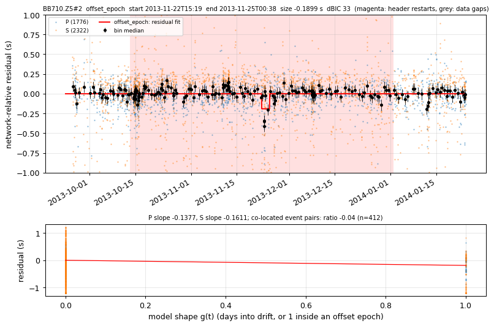

### GB220.Z5#1 to review

unclear [P=S]; start 2014-03-10T14:01:40Z (sd 14.62 d), end 2014-07-17T08:49:33Z [2014-07-16T15:52:47Z .. 2014-07-18T01:46:18Z], restart nan; size -0.0011375 +- 0.00035 s/day (residuals), CC +nan +- nan (n=0); dBIC 32.4, p 0.00498

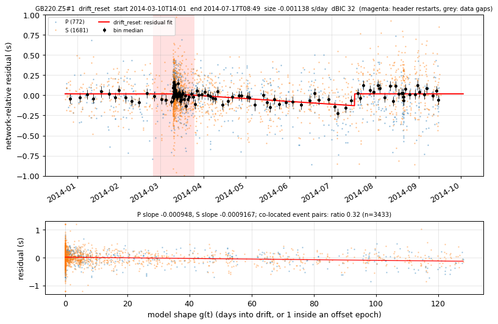

### J30C.7D#2 to review

unclear [P=S] {colocated~0}; start 2014-05-10T19:43:40Z (sd 0.14 d), end 2014-05-14T07:27:14Z [2014-05-14T05:53:47Z .. 2014-05-14T09:00:41Z], restart nan; size +0.18334 +- 0.028 s/day (residuals), CC +nan +- nan (n=0); dBIC 31.9, p 0.00498

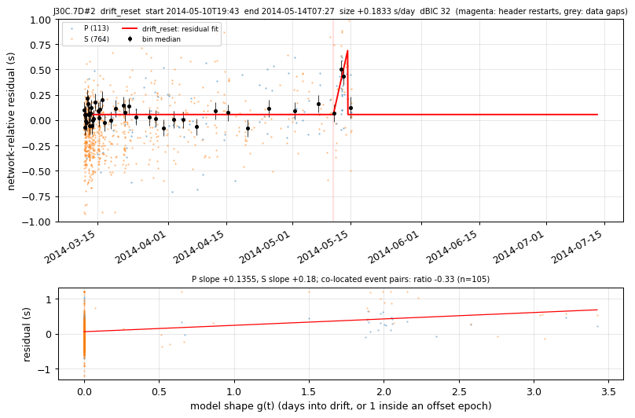